# Data_analysis

```python
import pandas as pd
import numpy as np
import matplotlib.pyplot as plt
import seaborn as sns
import arxivscraper
import datetime
import gender_guesser.detector as gender

%matplotlib inline
```

## Import previously scraped data

```python
dfcond = pd.read_csv('Data/arxiv_cond_2012_2020.csv',converters={'authors': eval})
dfastro = pd.read_csv('Data/arxiv_astro_2012_2020.csv',converters={'authors': eval})
```

```python
dfcond['first_author']=dfcond['authors'].apply(lambda x:x[0].split(' ')[0])
dfastro['first_author']=dfastro['authors'].apply(lambda x:x[0].split(' ')[0])
```

We will start by taking a look at the data from the condensed matter category and then we will repeat the analysis for the astrophysics one as a measure of consistency

# Analysis of condensed matter data

### Data preparation

First we prepare the dataset for the analysis by dropping some entries that cannot be used.

For many arXiv submissions the authors only provide initials for their first and middle name. These entries cannot be used to build a statistics concerning the gender of the authors and I therefore proceed with removing them.

To simplify I only check that the first author has entered a full name assuming that if only initials are used it is likely that that would be the case for all authors. Remember that we are also only concerned with the first and last author in this analysis.

```python
# First we split the author list and returning the first name of the first and last authors in a new columns
# We then drop the authors column for clarity
dfcond['first_author']=dfcond['authors'].apply(lambda x:x[0].split(' ')[0])
dfcond['last_author']=dfcond['authors'].apply(lambda x:x[-1].split(' ')[0])
dfcond.drop('authors',inplace=True,axis=1)

#Drop all the rows for which the author's name is shorter than 3 characters
#This is done to include punctuation in the initials since the split of the author list is done using a single space
#This passage can be improves as it removes from the dataset also authors with a two-letter first name
dfcond.drop(dfcond[dfcond['first_author'].map(len)<3].index, inplace=True)

#We transform the created columns into a datetime column
#We also drop all the entries that were created before 2012 but entered the data set because modified after 2012
dfcond['created'] = pd.to_datetime(dfcond['created'],format='%Y-%m-%d')
dfcond.drop(dfcond[dfcond['created'].dt.year<2012].index,inplace=True)

#Finally we reset the dataframe index
dfcond.reset_index(drop=True, inplace=True)
```

We then proceed with detecting the gender of the first and last author of the manuscript using the gender.Detector method of the gender_guesser library.

```python
# We capitalize the names as this is required for the gender guesser method to work correctly
dfcond['first_author'] = dfcond['first_author'].apply(lambda x:x.capitalize())
dfcond['last_author'] = dfcond['last_author'].apply(lambda x:x.capitalize())

# We instantiate a gender detector object and run it on the first and last author columns separately
detect = gender.Detector()
dfcond['gender_first']=dfcond['first_author'].map(detect.get_gender)
dfcond['gender_last']=dfcond['last_author'].map(detect.get_gender)

# We then split the dataframe in two to better handle separately the two data sets
# This is useful to more easily handle cases where the gender of the first author is clearly identifyed
# but not that of the last author, or viceversa. This approach can likely be improved
# We also rename the columns for simplicity

dfcondfirst = dfcond.loc[:,['created','first_author','gender_first']]
dfcondfirst.rename(columns={'created':'date','first_author':'author','gender_first':'gender'},inplace=True)
dfcondlast = dfcond.loc[:,['created','last_author','gender_last']]
dfcondlast.rename(columns={'created':'date','last_author':'author','gender_last':'gender'},inplace=True)

# Finally we map the results of the gender guesser so that 'mostly male' and 'mostly female'
# are transformed to 'male' and 'female' respectively. The gender guesser also return 'andy' when the name
# has equal likelihood of being male or female and 'uknown' when no record of the name is found
# We drop all the rows associated to names with these last two tags

dfcondfirst['gender'] = dfcondfirst['gender'].map({'male':'male','mostly_male':'male','mostly_female':'female',
                                                       'female':'female'})
dfcondfirst.dropna(inplace=True)

dfcondlast['gender'] = dfcondlast['gender'].map({'male':'male','mostly_male':'male','mostly_female':'female',
                                                       'female':'female'})
dfcondlast.dropna(inplace=True)
```

We check what we are left with

```python
dfcondlast.info()
```

```
<class 'pandas.core.frame.DataFrame'>
Int64Index: 76321 entries, 0 to 107357
Data columns (total 3 columns):
 #   Column  Non-Null Count  Dtype
---  ------  --------------  -----
 0   date    76321 non-null  datetime64[ns]
 1   author  76321 non-null  object
 2   gender  76321 non-null  object
dtypes: datetime64[ns](1), object(2)
memory usage: 4.8+ MB
```

So it looks like we have a decently sized data set that we can work with.

### Some simple data visualization

Simple histogram plot of the total number of submissions by year and by gender of the first author. We limit this to the year for which we have a full dataset

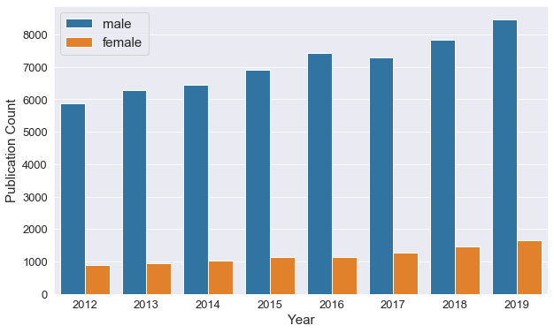

```python
fig = plt.figure(figsize = (10,6))

sns.countplot(x=dfcondfirst[dfcondfirst['date'].dt.year<2020]['date'].dt.year,
              data = dfcondfirst[dfcondfirst['date'].dt.year<2020],hue='gender');

plt.xlabel('Year', fontsize=15);
plt.ylabel('Publication Count', fontsize=15);
plt.xticks(size=13);
plt.yticks(size=13);
plt.legend(fontsize=15);
```

Simple histogram plot of the total number of submissions by year and by gender of the last author

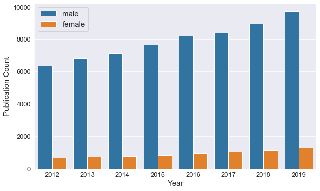

```python
ffig = plt.figure(figsize = (10,6))

sns.countplot(x=dfcondlast[dfcondlast['date'].dt.year<2020]['date'].dt.year,
              data = dfcondlast[dfcondlast['date'].dt.year<2020],hue='gender');

plt.xlabel('Year', fontsize=15);
plt.ylabel('Publication Count', fontsize=15);
plt.xticks(size=13);
plt.yticks(size=13);
plt.legend(fontsize=15);
```

Histogram plots of the total number of submissions separated by month by year and by gender of the first author.

This allows us to see more in details the effect on the first months of 2020.

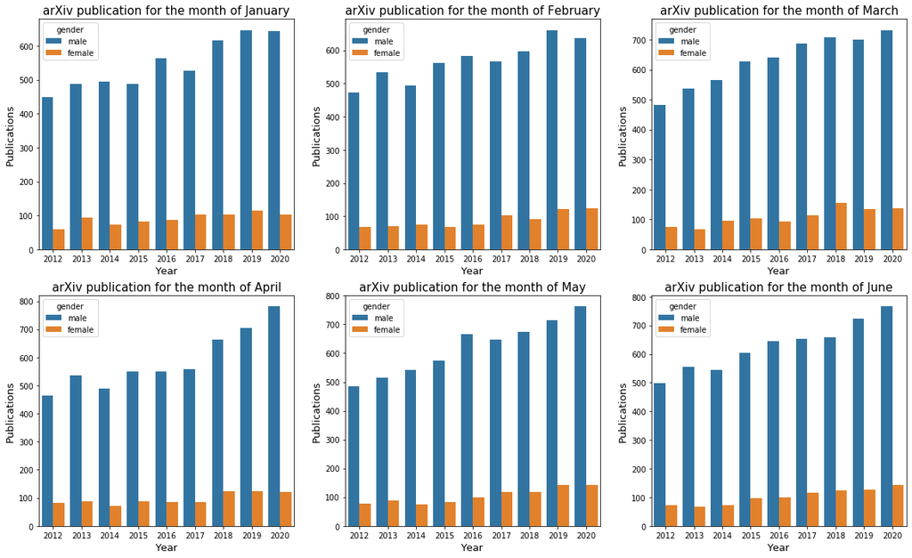

```python
fig, axes = plt.subplots(2,3, figsize=(20,12))
d = {1:'January',2:'February',3:'March',4:'April',5:'May',6:'June'}

for key,month in d.items():

        sns.countplot(dfcondfirst[dfcondfirst['date'].dt.month==key]['date'].dt.year,
              data = dfcondfirst[dfcondfirst['date'].dt.month==key], hue='gender',ax=axes[int(np.floor((key-1)/3)),
                                                                                          int((key-1)-np.floor((key-1)/3)*3)])
        axes[int(np.floor((key-1)/3)),
             int((key-1)-np.floor((key-1)/3)*3)].set_title('arXiv publication for the month of %s' % month, size = 15);
        axes[int(np.floor((key-1)/3)),
             int((key-1)-np.floor((key-1)/3)*3)].set_xlabel('Year', size = 13);
        axes[int(np.floor((key-1)/3)),
             int((key-1)-np.floor((key-1)/3)*3)].set_ylabel('Publications',size=13);
```

### Gender ratio

We now want to extract the ratio of female authors to analyze how this factor has changed in time in the past 8 years

```python
# We create a small function to create a dataframe for the evolution of the gender publication ratio
# we sample the data by month

def GenderRatio(df):

    ratio = []
    years = df['date'].dt.year.unique()
    months = df['date'].dt.month.unique()

    for year in years:

        try:
            for month in months:

                [a,b] = df[(df['date'].dt.year==year)
                             & (df['date'].dt.month==month)]['gender'].value_counts()
                ratio.append(b/(a+b))
        except:
            break

    time = pd.date_range(start=str(months[0])+'/'+str(years[0]),end=str(month)+'/'+str(year),freq='m');

    return pd.DataFrame(ratio,time,columns=['Percentage Female Author'])
```

```python
# Use function to create the dataframe

GndRtCondFirst = GenderRatio(dfcondfirst)
```

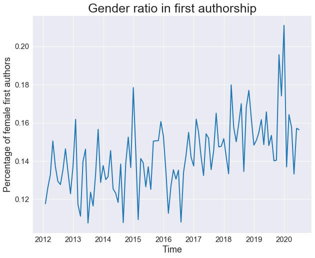

```python
# Visualization of the female/male first author ratio between 2012 and 2020

fig = plt.figure(figsize = (10,8))

sns.set_style('darkgrid')
sns.lineplot(data=GndRtCondFirst,lw=2,legend=False)

plt.title('Gender ratio in first authorship',size=25)
plt.xlabel('Time',size=18);
plt.ylabel('Percentage of female first authors',size=18);
plt.xticks(fontsize=15);
plt.yticks(fontsize=15);
```

```python
# We look at some descriptive statistics to better understand the variability of the data

STD = GndRtCondFirst.groupby(GndRtCondFirst.index.year).std()
AVE = GndRtCondFirst.groupby(GndRtCondFirst.index.year).mean()
AVE.rename(columns={'Percentage Female Author':'Mean'},inplace=True)
STD.rename(columns={'Percentage Female Author':'Standard Deviation'},inplace=True)

STAT = pd.concat((AVE,STD),axis=1)
STAT
```

|  | Mean | Standard Deviation |
| --- | --- | --- |
| 2012 | 0.133111 | 0.009327 |
| 2013 | 0.131658 | 0.017457 |
| 2014 | 0.135563 | 0.018113 |
| 2015 | 0.140613 | 0.014425 |
| 2016 | 0.132839 | 0.012711 |
| 2017 | 0.149242 | 0.009646 |
| 2018 | 0.156867 | 0.015564 |
| 2019 | 0.162020 | 0.021869 |
| 2020 | 0.150913 | 0.012663 |

```python
# We use the function previously created to repeat the analysis for the last author

GndRtCondLast = GenderRatio(dfcondlast)
```

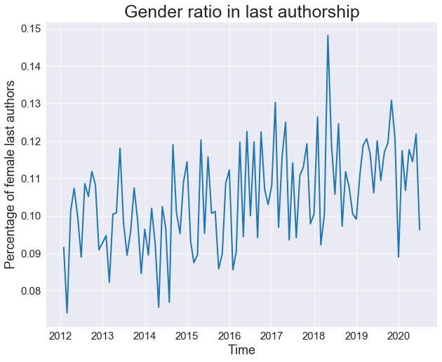

```python
fig = plt.figure(figsize = (10,8))

sns.set_style('darkgrid')
chart = sns.lineplot(data=GndRtCondLast,lw=2,legend=False)

plt.title('Gender ratio in last authorship',size=25)
plt.xlabel('Time',size=18);
plt.ylabel('Percentage of female last authors',size=18);
plt.xticks(fontsize=15);
plt.yticks(fontsize=15);
```

```python
# We look at some descriptive statistics to better understand the variability of the data

STD = GndRtCondLast.groupby(GndRtCondLast.index.year).std()
AVE = GndRtCondLast.groupby(GndRtCondLast.index.year).mean()
AVE.rename(columns={'Percentage Female Author':'Mean'},inplace=True)
STD.rename(columns={'Percentage Female Author':'Standard Deviation'},inplace=True)

STAT = pd.concat((AVE,STD),axis=1)
STAT
```

|  | Mean | Standard Deviation |
| --- | --- | --- |
| 2012 | 0.098357 | 0.011001 |
| 2013 | 0.097226 | 0.009611 |
| 2014 | 0.097847 | 0.013247 |
| 2015 | 0.099999 | 0.011752 |
| 2016 | 0.105588 | 0.013122 |
| 2017 | 0.109251 | 0.012456 |
| 2018 | 0.111059 | 0.015978 |
| 2019 | 0.114944 | 0.010373 |
| 2020 | 0.112391 | 0.009362 |

We now repeat the analysis for the publication data in the astrophysics category

# Analysis of astro data

### Data preparation

```python
dfastro['first_author']=dfastro['authors'].apply(lambda x:x[0].split(' ')[0])
dfastro['last_author']=dfastro['authors'].apply(lambda x:x[-1].split(' ')[0])
dfastro.drop('authors',inplace=True,axis=1)

dfastro.drop(dfastro[dfastro['first_author'].map(len)<3].index, inplace=True)

dfastro['created'] = pd.to_datetime(dfastro['created'],format='%Y-%m-%d')
dfastro.drop(dfastro[dfastro['created'].dt.year<2012].index,inplace=True)

dfastro.reset_index(drop=True, inplace=True)
```

```python
dfastro['first_author'] = dfastro['first_author'].apply(lambda x:x.capitalize())
dfastro['last_author'] = dfastro['last_author'].apply(lambda x:x.capitalize())

detect = gender.Detector()
dfastro['gender_first']=dfastro['first_author'].map(detect.get_gender)
dfastro['gender_last']=dfastro['last_author'].map(detect.get_gender)

dfastrofirst = dfastro.loc[:,['created','first_author','gender_first']]
dfastrofirst.rename(columns={'created':'date','first_author':'author','gender_first':'gender'},inplace=True)
dfastrolast = dfastro.loc[:,['created','last_author','gender_last']]
dfastrolast.rename(columns={'created':'date','last_author':'author','gender_last':'gender'},inplace=True)

dfastrofirst['gender'] = dfastrofirst['gender'].map({'male':'male','mostly_male':'male','mostly_female':'female',
                                                       'female':'female'})
dfastrofirst.dropna(inplace=True)

dfastrolast['gender'] = dfastrolast['gender'].map({'male':'male','mostly_male':'male','mostly_female':'female',
                                                       'female':'female'})
dfastrolast.dropna(inplace=True)
```

```python
dfastrolast.info()
```

```
<class 'pandas.core.frame.DataFrame'>
Int64Index: 67331 entries, 1 to 87515
Data columns (total 3 columns):
 #   Column  Non-Null Count  Dtype
---  ------  --------------  -----
 0   date    67331 non-null  datetime64[ns]
 1   author  67331 non-null  object
 2   gender  67331 non-null  object
dtypes: datetime64[ns](1), object(2)
memory usage: 4.6+ MB
```

### Data visualization

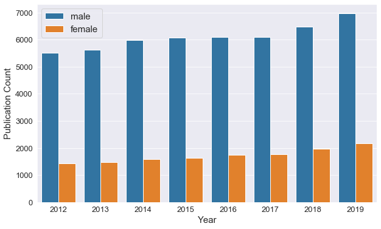

```python
fig = plt.figure(figsize = (10,6))

sns.countplot(x=dfastrofirst[dfastrofirst['date'].dt.year<2020]['date'].dt.year,
              data = dfastrofirst[dfastrofirst['date'].dt.year<2020],hue='gender');

plt.xlabel('Year', fontsize=15);
plt.ylabel('Publication Count', fontsize=15);
plt.xticks(size=13);
plt.yticks(size=13);
plt.legend(fontsize=15);
```

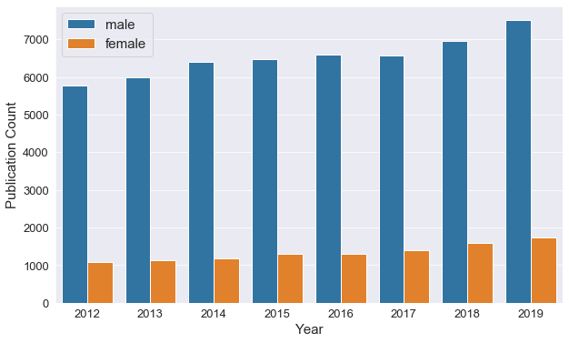

```python
fig = plt.figure(figsize = (10,6))

sns.countplot(x=dfastrolast[dfastrolast['date'].dt.year<2020]['date'].dt.year,
              data = dfastrolast[dfastrolast['date'].dt.year<2020],hue='gender');

plt.xlabel('Year', fontsize=15);
plt.ylabel('Publication Count', fontsize=15);
plt.xticks(size=13);
plt.yticks(size=13);
plt.legend(fontsize=15);
```

Breakdown by month

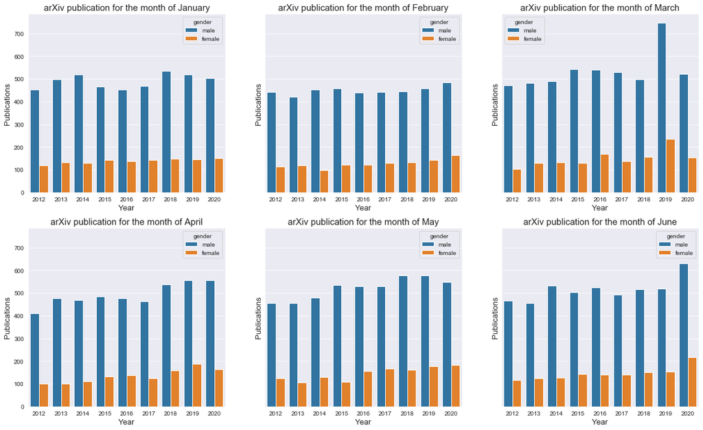

```python
fig, axes = plt.subplots(2,3, figsize=(20,12),sharey=True)
d = {1:'January',2:'February',3:'March',4:'April',5:'May',6:'June'}

for key,month in d.items():

        sns.countplot(dfastrofirst[dfastrofirst['date'].dt.month==key]['date'].dt.year,
              data = dfastrofirst[dfastrofirst['date'].dt.month==key],
                      hue='gender',hue_order = ['male','female'], ax=axes[int(np.floor((key-1)/3)),
                                                                            int((key-1)-np.floor((key-1)/3)*3)])
        axes[int(np.floor((key-1)/3)),
             int((key-1)-np.floor((key-1)/3)*3)].set_title('arXiv publication for the month of %s' % month, size = 15);
        axes[int(np.floor((key-1)/3)),
             int((key-1)-np.floor((key-1)/3)*3)].set_xlabel('Year', size = 13);
        axes[int(np.floor((key-1)/3)),
             int((key-1)-np.floor((key-1)/3)*3)].set_ylabel('Publications',size=13);
```

### Gender ratio

```python
# Use function to create the dataframe

GndRtAstroFirst = GenderRatio(dfastrofirst)
```

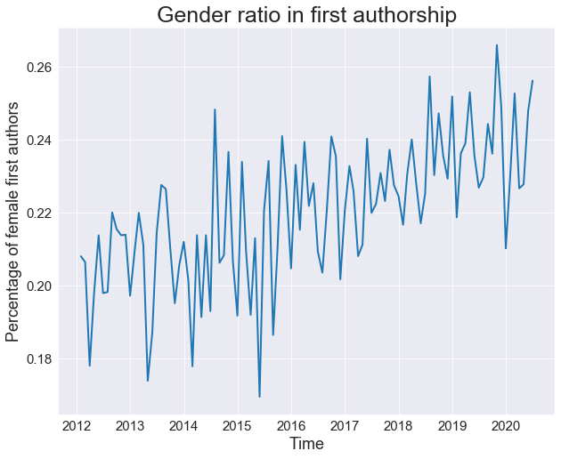

```python
# Visualization of the female/male first author ratio between 2012 and 2020

fig = plt.figure(figsize = (10,8))

sns.set_style('darkgrid')
sns.lineplot(data=GndRtAstroFirst,lw=2,legend=False)

plt.title('Gender ratio in first authorship',size=25)
plt.xlabel('Time',size=18);
plt.ylabel('Percentage of female first authors',size=18);
plt.xticks(fontsize=15);
plt.yticks(fontsize=15);
```

```python
# We look at some descriptive statistics to better understand the variability of the data

STD = GndRtAstroFirst.groupby(GndRtAstroFirst.index.year).std()
AVE = GndRtAstroFirst.groupby(GndRtAstroFirst.index.year).mean()
AVE.rename(columns={'Percentage Female Author':'Mean'},inplace=True)
STD.rename(columns={'Percentage Female Author':'Standard Deviation'},inplace=True)

STAT = pd.concat((AVE,STD),axis=1)
STAT
```

|  | Mean | Standard Deviation |
| --- | --- | --- |
| 2012 | 0.205091 | 0.011741 |
| 2013 | 0.207777 | 0.015702 |
| 2014 | 0.207457 | 0.019612 |
| 2015 | 0.211755 | 0.021335 |
| 2016 | 0.222557 | 0.013338 |
| 2017 | 0.225338 | 0.009518 |
| 2018 | 0.234113 | 0.012879 |
| 2019 | 0.237080 | 0.015096 |
| 2020 | 0.240362 | 0.013388 |

```python
# Last author

GndRtAstroLast = GenderRatio(dfastrolast)
```

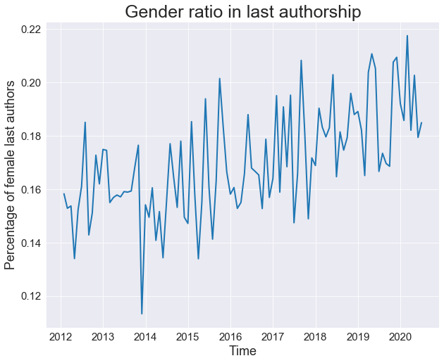

```python
# Visualization of the female/male Last author ratio between 2012 and 2020

fig = plt.figure(figsize = (10,8))

sns.set_style('darkgrid')
sns.lineplot(data=GndRtAstroLast,lw=2,legend=False)

plt.title('Gender ratio in last authorship',size=25)
plt.xlabel('Time',size=18);
plt.ylabel('Percentage of female last authors',size=18);
plt.xticks(fontsize=15);
plt.yticks(fontsize=15);
```

```python
# We look at some descriptive statistics to better understand the variability of the data

STD = GndRtAstroLast.groupby(GndRtAstroLast.index.year).std()
AVE = GndRtAstroLast.groupby(GndRtAstroLast.index.year).mean()
AVE.rename(columns={'Percentage Female Author':'Mean'},inplace=True)
STD.rename(columns={'Percentage Female Author':'Standard Deviation'},inplace=True)

STAT = pd.concat((AVE,STD),axis=1)
STAT
```

|  | Mean | Standard Deviation |
| --- | --- | --- |
| 2012 | 0.158395 | 0.014108 |
| 2013 | 0.157557 | 0.015788 |
| 2014 | 0.155091 | 0.013136 |
| 2015 | 0.166721 | 0.020470 |
| 2016 | 0.164548 | 0.010482 |
| 2017 | 0.175085 | 0.019276 |
| 2018 | 0.184343 | 0.009959 |
| 2019 | 0.187865 | 0.018741 |
| 2020 | 0.192057 | 0.014911 |

## Conclusions

From analyzing the number of publications in the context of the past 8 years, it appears that we can exclude the presence of a strong negative impact of COVID-19 on the number of publications from female authors, at least for what concerns the field of Physics.